# Mini project 1 - Basic Data Analytics with Pandas

In the first week, we’ll practice data exploration and data analysis in Python with a real-world dataset – Sberbank data, which is available in the [Sberbank Russian Housing Market Kaggle competition](https://www.kaggle.com/c/sberbank-russian-housing-market). Sberbank dataset contains rich and messy data about Russian's housing market. This real-world data will provide you concrete practices for getting started with python.

This step-by-step mini project will cover the most essential and useful techniques for data analysis in solving a real-world problem with key Python data analysis libraries: pandas and numpy. We’ll go through data loading and data frame creation, selection and query, grouping and function applying, plotting and writing data to file.

```python
# Start with importing essentials
import pandas as pd
import numpy as np
import matplotlib.pyplot as plt
%matplotlib inline
```

**Question 1: Read the train set and test set of Sberbank dataset from the train.csv and test.csv, and call them train_data and test_data.**

Hint: You can read data from a CSV file using the read_csv function in pandas. By default, it assumes that the fields are comma-separated.

```python
train_data = pd.read_csv('train.csv')
test_data = pd.read_csv('test.csv')
```

```python
train_data.head()
```

|  | id | timestamp | full_sq | life_sq | floor | max_floor | material | build_year | num_room | kitch_sq | ... | cafe_count_5000_price_2500 | cafe_count_5000_price_4000 | cafe_count_5000_price_high | big_church_count_5000 | church_count_5000 | mosque_count_5000 | leisure_count_5000 | sport_count_5000 | market_count_5000 | price_doc |
| --- | --- | --- | --- | --- | --- | --- | --- | --- | --- | --- | --- | --- | --- | --- | --- | --- | --- | --- | --- | --- | --- |
| 0 | 1 | 2011-08-20 | 43 | 27.0 | 4.0 | NaN | NaN | NaN | NaN | NaN | ... | 9 | 4 | 0 | 13 | 22 | 1 | 0 | 52 | 4 | 5850000 |
| 1 | 2 | 2011-08-23 | 34 | 19.0 | 3.0 | NaN | NaN | NaN | NaN | NaN | ... | 15 | 3 | 0 | 15 | 29 | 1 | 10 | 66 | 14 | 6000000 |
| 2 | 3 | 2011-08-27 | 43 | 29.0 | 2.0 | NaN | NaN | NaN | NaN | NaN | ... | 10 | 3 | 0 | 11 | 27 | 0 | 4 | 67 | 10 | 5700000 |
| 3 | 4 | 2011-09-01 | 89 | 50.0 | 9.0 | NaN | NaN | NaN | NaN | NaN | ... | 11 | 2 | 1 | 4 | 4 | 0 | 0 | 26 | 3 | 13100000 |
| 4 | 5 | 2011-09-05 | 77 | 77.0 | 4.0 | NaN | NaN | NaN | NaN | NaN | ... | 319 | 108 | 17 | 135 | 236 | 2 | 91 | 195 | 14 | 16331452 |

5 rows × 292 columns

```python
test_data.tail()
```

|  | id | timestamp | full_sq | life_sq | floor | max_floor | material | build_year | num_room | kitch_sq | ... | cafe_count_5000_price_1500 | cafe_count_5000_price_2500 | cafe_count_5000_price_4000 | cafe_count_5000_price_high | big_church_count_5000 | church_count_5000 | mosque_count_5000 | leisure_count_5000 | sport_count_5000 | market_count_5000 |
| --- | --- | --- | --- | --- | --- | --- | --- | --- | --- | --- | --- | --- | --- | --- | --- | --- | --- | --- | --- | --- | --- |
| 7657 | 38131 | 2016-05-26 | 52.20 | 31.8 | 10 | 12 | 5 | 1973.0 | 2 | 9.1 | ... | 81 | 28 | 1 | 1 | 8 | 39 | 2 | 3 | 75 | 12 |
| 7658 | 38132 | 2016-05-28 | 54.09 | NaN | 14 | 0 | 1 | NaN | 2 | 0.0 | ... | 1 | 2 | 1 | 0 | 0 | 10 | 0 | 0 | 0 | 0 |
| 7659 | 38133 | 2016-05-30 | 41.08 | 1.0 | 12 | 1 | 1 | 1.0 | 1 | 1.0 | ... | 636 | 371 | 141 | 26 | 150 | 249 | 2 | 105 | 203 | 13 |
| 7660 | 38134 | 2016-05-30 | 34.80 | 19.8 | 8 | 9 | 5 | 1977.0 | 1 | 6.4 | ... | 16 | 7 | 2 | 0 | 5 | 11 | 0 | 2 | 43 | 10 |
| 7661 | 38135 | 2016-05-30 | 63.00 | 43.8 | 5 | 5 | 1 | 1973.0 | 3 | 7.1 | ... | 31 | 11 | 1 | 0 | 6 | 26 | 1 | 4 | 42 | 11 |

5 rows × 291 columns

**Question 2: Merge train and test to one dataframe and call it full_data.**

Hint: The new dataframe should have the rows from train_data followed by rows from test_data. Refer to [merge, join, and concatenate](https://pandas.pydata.org/pandas-docs/stable/merging.html).

```python
full_data = pd.concat([train_data,test_data], ignore_index=True)
#full_data = train_data.append(test_data, ignore_index=True)
```

*For the rest questions, if not specified, we'll do practice on train_data. Let's create a dataframe called df from train_data.*

```python
df = train_data
```

```python
df.head(10)
```

|  | id | timestamp | full_sq | life_sq | floor | max_floor | material | build_year | num_room | kitch_sq | ... | cafe_count_5000_price_2500 | cafe_count_5000_price_4000 | cafe_count_5000_price_high | big_church_count_5000 | church_count_5000 | mosque_count_5000 | leisure_count_5000 | sport_count_5000 | market_count_5000 | price_doc |
| --- | --- | --- | --- | --- | --- | --- | --- | --- | --- | --- | --- | --- | --- | --- | --- | --- | --- | --- | --- | --- | --- |
| 0 | 1 | 2011-08-20 | 43 | 27.0 | 4.0 | NaN | NaN | NaN | NaN | NaN | ... | 9 | 4 | 0 | 13 | 22 | 1 | 0 | 52 | 4 | 5850000 |
| 1 | 2 | 2011-08-23 | 34 | 19.0 | 3.0 | NaN | NaN | NaN | NaN | NaN | ... | 15 | 3 | 0 | 15 | 29 | 1 | 10 | 66 | 14 | 6000000 |
| 2 | 3 | 2011-08-27 | 43 | 29.0 | 2.0 | NaN | NaN | NaN | NaN | NaN | ... | 10 | 3 | 0 | 11 | 27 | 0 | 4 | 67 | 10 | 5700000 |
| 3 | 4 | 2011-09-01 | 89 | 50.0 | 9.0 | NaN | NaN | NaN | NaN | NaN | ... | 11 | 2 | 1 | 4 | 4 | 0 | 0 | 26 | 3 | 13100000 |
| 4 | 5 | 2011-09-05 | 77 | 77.0 | 4.0 | NaN | NaN | NaN | NaN | NaN | ... | 319 | 108 | 17 | 135 | 236 | 2 | 91 | 195 | 14 | 16331452 |
| 5 | 6 | 2011-09-06 | 67 | 46.0 | 14.0 | NaN | NaN | NaN | NaN | NaN | ... | 62 | 14 | 1 | 53 | 78 | 1 | 20 | 113 | 17 | 9100000 |
| 6 | 7 | 2011-09-08 | 25 | 14.0 | 10.0 | NaN | NaN | NaN | NaN | NaN | ... | 81 | 16 | 3 | 38 | 80 | 1 | 27 | 127 | 8 | 5500000 |
| 7 | 8 | 2011-09-09 | 44 | 44.0 | 5.0 | NaN | NaN | NaN | NaN | NaN | ... | 9 | 4 | 0 | 11 | 18 | 1 | 0 | 47 | 4 | 2000000 |
| 8 | 9 | 2011-09-10 | 42 | 27.0 | 5.0 | NaN | NaN | NaN | NaN | NaN | ... | 19 | 8 | 1 | 18 | 34 | 1 | 3 | 85 | 11 | 5300000 |
| 9 | 10 | 2011-09-13 | 36 | 21.0 | 9.0 | NaN | NaN | NaN | NaN | NaN | ... | 19 | 13 | 0 | 10 | 20 | 1 | 3 | 67 | 1 | 2000000 |

10 rows × 292 columns

**Question 4: How many columns and rows are there in the data?**

```python
df.shape
# There are 30471 rows and 292 columns in the data.
```

```
(30471, 292)
```

**Question 5: Which features are available in the data? Display the features.**

Hint: The features are the column names. You can print them out.

```python
df.columns.values
```

```
array(['id', 'timestamp', 'full_sq', 'life_sq', 'floor', 'max_floor',
       'material', 'build_year', 'num_room', 'kitch_sq', 'state',
       'product_type', 'sub_area', 'area_m', 'raion_popul',
       'green_zone_part', 'indust_part', 'children_preschool',
       'preschool_quota', 'preschool_education_centers_raion',
       'children_school', 'school_quota', 'school_education_centers_raion',
       'school_education_centers_top_20_raion', 'hospital_beds_raion',
       'healthcare_centers_raion', 'university_top_20_raion',
       'sport_objects_raion', 'additional_education_raion',
       'culture_objects_top_25', 'culture_objects_top_25_raion',
       'shopping_centers_raion', 'office_raion',
       'thermal_power_plant_raion', 'incineration_raion',
       'oil_chemistry_raion', 'radiation_raion', 'railroad_terminal_raion',
       'big_market_raion', 'nuclear_reactor_raion',
       'detention_facility_raion', 'full_all', 'male_f', 'female_f',
       'young_all', 'young_male', 'young_female', 'work_all', 'work_male',
       'work_female', 'ekder_all', 'ekder_male', 'ekder_female', '0_6_all',
       '0_6_male', '0_6_female', '7_14_all', '7_14_male', '7_14_female',
       '0_17_all', '0_17_male', '0_17_female', '16_29_all', '16_29_male',
       '16_29_female', '0_13_all', '0_13_male', '0_13_female',
       'raion_build_count_with_material_info', 'build_count_block',
       'build_count_wood', 'build_count_frame', 'build_count_brick',
       'build_count_monolith', 'build_count_panel', 'build_count_foam',
       'build_count_slag', 'build_count_mix',
       'raion_build_count_with_builddate_info', 'build_count_before_1920',
       'build_count_1921-1945', 'build_count_1946-1970',
       'build_count_1971-1995', 'build_count_after_1995', 'ID_metro',
       'metro_min_avto', 'metro_km_avto', 'metro_min_walk',
       'metro_km_walk', 'kindergarten_km', 'school_km', 'park_km',
       'green_zone_km', 'industrial_km', 'water_treatment_km',
       'cemetery_km', 'incineration_km', 'railroad_station_walk_km',
       'railroad_station_walk_min', 'ID_railroad_station_walk',
       'railroad_station_avto_km', 'railroad_station_avto_min',
       'ID_railroad_station_avto', 'public_transport_station_km',
       'public_transport_station_min_walk', 'water_km', 'water_1line',
       'mkad_km', 'ttk_km', 'sadovoe_km', 'bulvar_ring_km', 'kremlin_km',
       'big_road1_km', 'ID_big_road1', 'big_road1_1line', 'big_road2_km',
       'ID_big_road2', 'railroad_km', 'railroad_1line',
       'zd_vokzaly_avto_km', 'ID_railroad_terminal',
       'bus_terminal_avto_km', 'ID_bus_terminal', 'oil_chemistry_km',
```

[output cut: 51 more lines]

```
       'cafe_count_3000_price_500', 'cafe_count_3000_price_1000',
       'cafe_count_3000_price_1500', 'cafe_count_3000_price_2500',
       'cafe_count_3000_price_4000', 'cafe_count_3000_price_high',
       'big_church_count_3000', 'church_count_3000', 'mosque_count_3000',
       'leisure_count_3000', 'sport_count_3000', 'market_count_3000',
       'green_part_5000', 'prom_part_5000', 'office_count_5000',
       'office_sqm_5000', 'trc_count_5000', 'trc_sqm_5000',
       'cafe_count_5000', 'cafe_sum_5000_min_price_avg',
       'cafe_sum_5000_max_price_avg', 'cafe_avg_price_5000',
       'cafe_count_5000_na_price', 'cafe_count_5000_price_500',
       'cafe_count_5000_price_1000', 'cafe_count_5000_price_1500',
       'cafe_count_5000_price_2500', 'cafe_count_5000_price_4000',
       'cafe_count_5000_price_high', 'big_church_count_5000',
       'church_count_5000', 'mosque_count_5000', 'leisure_count_5000',
       'sport_count_5000', 'market_count_5000', 'price_doc'], dtype=object)
```

**Question 6: What's the data type of each column? Save the datatype as data_type.**

```python
data_type = df.dtypes
```

[output not shown]

```python
for i in range(len(data_type)):
    print (data_type.index[i],data_type[i])
```

```
('id', dtype('int64'))
('timestamp', dtype('O'))
('full_sq', dtype('int64'))
('life_sq', dtype('float64'))
('floor', dtype('float64'))
('max_floor', dtype('float64'))
('material', dtype('float64'))
('build_year', dtype('float64'))
('num_room', dtype('float64'))
('kitch_sq', dtype('float64'))
('state', dtype('float64'))
('product_type', dtype('O'))
('sub_area', dtype('O'))
('area_m', dtype('float64'))
('raion_popul', dtype('int64'))
('green_zone_part', dtype('float64'))
('indust_part', dtype('float64'))
('children_preschool', dtype('int64'))
('preschool_quota', dtype('float64'))
('preschool_education_centers_raion', dtype('int64'))
('children_school', dtype('int64'))
('school_quota', dtype('float64'))
('school_education_centers_raion', dtype('int64'))
('school_education_centers_top_20_raion', dtype('int64'))
('hospital_beds_raion', dtype('float64'))
('healthcare_centers_raion', dtype('int64'))
('university_top_20_raion', dtype('int64'))
('sport_objects_raion', dtype('int64'))
('additional_education_raion', dtype('int64'))
('culture_objects_top_25', dtype('O'))
('culture_objects_top_25_raion', dtype('int64'))
('shopping_centers_raion', dtype('int64'))
('office_raion', dtype('int64'))
('thermal_power_plant_raion', dtype('O'))
('incineration_raion', dtype('O'))
('oil_chemistry_raion', dtype('O'))
('radiation_raion', dtype('O'))
('railroad_terminal_raion', dtype('O'))
('big_market_raion', dtype('O'))
('nuclear_reactor_raion', dtype('O'))
```

[output cut: 239 more lines]

[output not shown]

**Question 7: Which variables are numerical variables (excluding 'id')? Put all the numerical variable in list.**

```python
num_var = data_type[data_type!='object'].index.tolist()
num_var.remove('id')
print len(num_var)
```

```
275
```

**Question 8: Select the first 5 rows with 'id' (the 1st column) and 'price_doc' (the last column) columns from the data.**

Hint: You can find out several ways to solve this question.

```python
df[:5][['id', 'price_doc']]
# df.loc[:4, ['id', 'price_doc']]
```

|  | id | price_doc |
| --- | --- | --- |
| 0 | 1 | 5850000 |
| 1 | 2 | 6000000 |
| 2 | 3 | 5700000 |
| 3 | 4 | 13100000 |
| 4 | 5 | 16331452 |

**Question 9: Select the rows with the full area larger than 10 and smaller than 1500. Full area is indicated by 'full_sq'.**

Hint: You can use boolean indexing or query. Try both methods.

```python
#boolean indexing
df[(df.full_sq>10)&(df.full_sq<1500)]
#query
df.query('full_sq>10 and full_sq<1500')
```

|  | id | timestamp | full_sq | life_sq | floor | max_floor | material | build_year | num_room | kitch_sq | ... | cafe_count_5000_price_2500 | cafe_count_5000_price_4000 | cafe_count_5000_price_high | big_church_count_5000 | church_count_5000 | mosque_count_5000 | leisure_count_5000 | sport_count_5000 | market_count_5000 | price_doc |
| --- | --- | --- | --- | --- | --- | --- | --- | --- | --- | --- | --- | --- | --- | --- | --- | --- | --- | --- | --- | --- | --- |
| 0 | 1 | 2011-08-20 | 43 | 27.0 | 4.0 | NaN | NaN | NaN | NaN | NaN | ... | 9 | 4 | 0 | 13 | 22 | 1 | 0 | 52 | 4 | 5850000 |
| 1 | 2 | 2011-08-23 | 34 | 19.0 | 3.0 | NaN | NaN | NaN | NaN | NaN | ... | 15 | 3 | 0 | 15 | 29 | 1 | 10 | 66 | 14 | 6000000 |
| 2 | 3 | 2011-08-27 | 43 | 29.0 | 2.0 | NaN | NaN | NaN | NaN | NaN | ... | 10 | 3 | 0 | 11 | 27 | 0 | 4 | 67 | 10 | 5700000 |
| 3 | 4 | 2011-09-01 | 89 | 50.0 | 9.0 | NaN | NaN | NaN | NaN | NaN | ... | 11 | 2 | 1 | 4 | 4 | 0 | 0 | 26 | 3 | 13100000 |
| 4 | 5 | 2011-09-05 | 77 | 77.0 | 4.0 | NaN | NaN | NaN | NaN | NaN | ... | 319 | 108 | 17 | 135 | 236 | 2 | 91 | 195 | 14 | 16331452 |
| 5 | 6 | 2011-09-06 | 67 | 46.0 | 14.0 | NaN | NaN | NaN | NaN | NaN | ... | 62 | 14 | 1 | 53 | 78 | 1 | 20 | 113 | 17 | 9100000 |
| 6 | 7 | 2011-09-08 | 25 | 14.0 | 10.0 | NaN | NaN | NaN | NaN | NaN | ... | 81 | 16 | 3 | 38 | 80 | 1 | 27 | 127 | 8 | 5500000 |
| 7 | 8 | 2011-09-09 | 44 | 44.0 | 5.0 | NaN | NaN | NaN | NaN | NaN | ... | 9 | 4 | 0 | 11 | 18 | 1 | 0 | 47 | 4 | 2000000 |
| 8 | 9 | 2011-09-10 | 42 | 27.0 | 5.0 | NaN | NaN | NaN | NaN | NaN | ... | 19 | 8 | 1 | 18 | 34 | 1 | 3 | 85 | 11 | 5300000 |
| 9 | 10 | 2011-09-13 | 36 | 21.0 | 9.0 | NaN | NaN | NaN | NaN | NaN | ... | 19 | 13 | 0 | 10 | 20 | 1 | 3 | 67 | 1 | 2000000 |
| 10 | 11 | 2011-09-16 | 36 | 19.0 | 12.0 | NaN | NaN | NaN | NaN | NaN | ... | 1 | 1 | 0 | 5 | 9 | 0 | 2 | 17 | 6 | 4650000 |
| 11 | 12 | 2011-09-16 | 38 | 19.0 | 11.0 | NaN | NaN | NaN | NaN | NaN | ... | 8 | 3 | 0 | 10 | 9 | 0 | 0 | 35 | 4 | 4800000 |
| 12 | 13 | 2011-09-17 | 43 | 28.0 | 4.0 | NaN | NaN | NaN | NaN | NaN | ... | 13 | 9 | 1 | 7 | 15 | 0 | 2 | 47 | 0 | 5100000 |
| 13 | 14 | 2011-09-19 | 31 | 31.0 | 4.0 | NaN | NaN | NaN | NaN | NaN | ... | 254 | 108 | 22 | 57 | 102 | 1 | 72 | 166 | 7 | 5200000 |
| 14 | 15 | 2011-09-19 | 31 | 21.0 | 3.0 | NaN | NaN | NaN | NaN | NaN | ... | 88 | 19 | 2 | 63 | 100 | 0 | 28 | 132 | 14 | 5000000 |
| 15 | 16 | 2011-09-20 | 51 | 31.0 | 15.0 | NaN | NaN | NaN | NaN | NaN | ... | 6 | 1 | 0 | 9 | 21 | 0 | 1 | 53 | 9 | 1850000 |
| 16 | 17 | 2011-09-20 | 47 | 31.0 | 4.0 | NaN | NaN | NaN | NaN | NaN | ... | 10 | 2 | 0 | 7 | 23 | 0 | 4 | 62 | 13 | 6300000 |
| 17 | 18 | 2011-09-20 | 42 | 28.0 | 2.0 | NaN | NaN | NaN | NaN | NaN | ... | 32 | 6 | 0 | 13 | 33 | 1 | 10 | 72 | 12 | 5900000 |
| 18 | 19 | 2011-09-22 | 59 | 33.0 | 10.0 | NaN | NaN | NaN | NaN | NaN | ... | 1 | 1 | 0 | 6 | 9 | 0 | 2 | 17 | 6 | 7900000 |
| 19 | 20 | 2011-09-22 | 44 | 29.0 | 4.0 | NaN | NaN | NaN | NaN | NaN | ... | 9 | 2 | 0 | 10 | 14 | 0 | 2 | 51 | 5 | 5200000 |
| 20 | 21 | 2011-09-22 | 74 | 44.0 | 10.0 | NaN | NaN | NaN | NaN | NaN | ... | 0 | 0 | 0 | 1 | 5 | 0 | 0 | 0 | 0 | 8200000 |
| 21 | 22 | 2011-09-22 | 39 | 39.0 | 7.0 | NaN | NaN | NaN | NaN | NaN | ... | 18 | 3 | 0 | 12 | 14 | 0 | 1 | 64 | 9 | 5200000 |
| 22 | 23 | 2011-09-23 | 48 | 34.0 | 6.0 | NaN | NaN | NaN | NaN | NaN | ... | 16 | 4 | 1 | 11 | 10 | 0 | 1 | 55 | 8 | 6250000 |
| 23 | 24 | 2011-09-23 | 32 | 18.0 | 3.0 | NaN | NaN | NaN | NaN | NaN | ... | 10 | 1 | 0 | 7 | 21 | 1 | 1 | 42 | 13 | 5750000 |
| 24 | 25 | 2011-09-23 | 34 | 19.0 | 11.0 | NaN | NaN | NaN | NaN | NaN | ... | 20 | 4 | 1 | 8 | 9 | 0 | 1 | 56 | 8 | 6000000 |
| 25 | 26 | 2011-09-24 | 45 | 29.0 | 9.0 | NaN | NaN | NaN | NaN | NaN | ... | 23 | 15 | 1 | 11 | 23 | 1 | 4 | 70 | 1 | 1050000 |
| 26 | 27 | 2011-09-26 | 35 | 20.0 | 4.0 | NaN | NaN | NaN | NaN | NaN | ... | 16 | 5 | 0 | 13 | 25 | 1 | 3 | 84 | 4 | 5000000 |
| 27 | 28 | 2011-09-26 | 38 | 20.0 | 6.0 | NaN | NaN | NaN | NaN | NaN | ... | 1 | 1 | 0 | 2 | 10 | 0 | 1 | 11 | 2 | 4700000 |
| 28 | 29 | 2011-09-26 | 73 | 38.0 | 15.0 | NaN | NaN | NaN | NaN | NaN | ... | 20 | 3 | 0 | 17 | 35 | 0 | 9 | 98 | 7 | 8254400 |
| 29 | 30 | 2011-09-27 | 42 | 27.0 | 3.0 | NaN | NaN | NaN | NaN | NaN | ... | 15 | 2 | 0 | 12 | 17 | 0 | 3 | 73 | 5 | 5900000 |
| ... | ... | ... | ... | ... | ... | ... | ... | ... | ... | ... | ... | ... | ... | ... | ... | ... | ... | ... | ... | ... | ... |
| 30441 | 30444 | 2015-06-27 | 113 | 1.0 | 26.0 | 26.0 | 1.0 | 2015.0 | 4.0 | 1.0 | ... | 371 | 141 | 26 | 150 | 249 | 2 | 105 | 203 | 13 | 25039300 |
| 30442 | 30445 | 2015-06-27 | 40 | 40.0 | 2.0 | 12.0 | 4.0 | 2015.0 | 1.0 | 10.0 | ... | 0 | 0 | 0 | 1 | 7 | 1 | 0 | 12 | 1 | 4350000 |
| 30443 | 30446 | 2015-06-27 | 79 | NaN | 17.0 | 17.0 | 1.0 | NaN | 3.0 | 79.0 | ... | 7 | 2 | 0 | 5 | 14 | 0 | 3 | 17 | 2 | 7567425 |
| 30444 | 30447 | 2015-06-27 | 85 | NaN | 20.0 | 25.0 | 4.0 | 2016.0 | 3.0 | 1.0 | ... | 13 | 4 | 1 | 5 | 7 | 0 | 1 | 38 | 5 | 11438948 |
| 30445 | 30448 | 2015-06-27 | 47 | 47.0 | 19.0 | 25.0 | 1.0 | 2016.0 | 1.0 | 1.0 | ... | 99 | 57 | 12 | 23 | 42 | 1 | 13 | 123 | 7 | 10139368 |
| 30446 | 30449 | 2015-06-27 | 82 | 82.0 | 8.0 | 8.0 | 6.0 | 2017.0 | 2.0 | 1.0 | ... | 2 | 2 | 0 | 2 | 9 | 0 | 0 | 7 | 2 | 6125400 |
| 30447 | 30450 | 2015-06-27 | 64 | NaN | 15.0 | 17.0 | 1.0 | NaN | 2.0 | 1.0 | ... | 7 | 2 | 0 | 5 | 14 | 0 | 3 | 17 | 2 | 6373324 |
| 30448 | 30451 | 2015-06-27 | 74 | NaN | 8.0 | 17.0 | 1.0 | NaN | 3.0 | 1.0 | ... | 1 | 0 | 0 | 1 | 7 | 0 | 0 | 8 | 0 | 6888144 |
| 30449 | 30452 | 2015-06-27 | 47 | 47.0 | 7.0 | 25.0 | 1.0 | 2015.0 | 1.0 | 1.0 | ... | 99 | 57 | 12 | 23 | 42 | 1 | 13 | 123 | 7 | 9227657 |
| 30450 | 30453 | 2015-06-29 | 65 | NaN | 5.0 | 0.0 | 1.0 | NaN | 2.0 | 0.0 | ... | 20 | 4 | 0 | 13 | 28 | 1 | 3 | 84 | 5 | 12610000 |
| 30451 | 30454 | 2015-06-29 | 37 | NaN | 3.0 | 3.0 | 1.0 | 0.0 | 1.0 | 1.0 | ... | 0 | 0 | 0 | 0 | 0 | 0 | 0 | 0 | 0 | 2394300 |
| 30452 | 30455 | 2015-06-29 | 38 | 19.0 | 7.0 | 17.0 | 1.0 | 2006.0 | 1.0 | 7.0 | ... | 26 | 12 | 0 | 8 | 23 | 1 | 4 | 67 | 2 | 6800000 |
| 30453 | 30456 | 2015-06-29 | 45 | 1.0 | 6.0 | 15.0 | 6.0 | 2015.0 | 1.0 | 1.0 | ... | 2 | 1 | 0 | 3 | 8 | 1 | 0 | 20 | 3 | 4066740 |
| 30454 | 30457 | 2015-06-29 | 40 | 26.0 | 3.0 | 9.0 | 2.0 | 1972.0 | 2.0 | 5.0 | ... | 25 | 3 | 0 | 17 | 29 | 0 | 8 | 90 | 4 | 6300000 |
| 30455 | 30458 | 2015-06-29 | 79 | 79.0 | 3.0 | 3.0 | 1.0 | NaN | 3.0 | 1.0 | ... | 1 | 1 | 0 | 2 | 12 | 0 | 1 | 10 | 0 | 9014972 |
| 30456 | 30459 | 2015-06-29 | 52 | 30.0 | 8.0 | 14.0 | 1.0 | 1992.0 | 2.0 | 8.0 | ... | 13 | 4 | 1 | 5 | 7 | 0 | 1 | 42 | 6 | 1000000 |
| 30457 | 30460 | 2015-06-29 | 58 | 43.0 | 7.0 | 9.0 | 1.0 | 1979.0 | 3.0 | 6.0 | ... | 5 | 0 | 0 | 8 | 7 | 1 | 1 | 36 | 1 | 7800000 |
| 30458 | 30461 | 2015-06-29 | 50 | 1.0 | 7.0 | 7.0 | 1.0 | 2015.0 | 1.0 | 0.0 | ... | 13 | 1 | 0 | 5 | 15 | 0 | 3 | 35 | 3 | 6370777 |
| 30459 | 30462 | 2015-06-29 | 51 | NaN | 4.0 | 17.0 | 4.0 | NaN | 2.0 | 1.0 | ... | 7 | 2 | 0 | 5 | 14 | 0 | 3 | 17 | 2 | 5778893 |
| 30460 | 30463 | 2015-06-29 | 54 | 32.0 | 8.0 | 16.0 | 1.0 | 1979.0 | 2.0 | 9.0 | ... | 8 | 0 | 0 | 6 | 25 | 0 | 1 | 32 | 8 | 9500000 |
| 30461 | 30464 | 2015-06-30 | 36 | 19.0 | 5.0 | 16.0 | 1.0 | 1980.0 | 1.0 | 8.0 | ... | 41 | 4 | 1 | 4 | 35 | 1 | 6 | 80 | 6 | 5000000 |
| 30462 | 30465 | 2015-06-30 | 47 | 30.0 | 23.0 | 25.0 | 4.0 | 2016.0 | 1.0 | 10.0 | ... | 99 | 57 | 12 | 23 | 42 | 1 | 13 | 123 | 7 | 10544070 |
| 30463 | 30466 | 2015-06-30 | 56 | 29.0 | 13.0 | 14.0 | 1.0 | 2001.0 | 2.0 | 11.0 | ... | 14 | 2 | 0 | 13 | 12 | 0 | 1 | 53 | 6 | 12000000 |
| 30464 | 30467 | 2015-06-30 | 56 | 51.0 | 19.0 | 19.0 | 1.0 | 2017.0 | 2.0 | 1.0 | ... | 25 | 3 | 0 | 14 | 29 | 1 | 4 | 90 | 6 | 10262010 |
| 30465 | 30468 | 2015-06-30 | 52 | NaN | 13.0 | 17.0 | 1.0 | NaN | 2.0 | 1.0 | ... | 371 | 141 | 26 | 150 | 249 | 2 | 105 | 203 | 13 | 6750554 |
| 30466 | 30469 | 2015-06-30 | 44 | 27.0 | 7.0 | 9.0 | 1.0 | 1975.0 | 2.0 | 6.0 | ... | 15 | 5 | 0 | 15 | 26 | 1 | 2 | 84 | 6 | 7400000 |
| 30467 | 30470 | 2015-06-30 | 86 | 59.0 | 3.0 | 9.0 | 2.0 | 1935.0 | 4.0 | 10.0 | ... | 313 | 128 | 24 | 98 | 182 | 1 | 82 | 171 | 15 | 25000000 |
| 30468 | 30471 | 2015-06-30 | 45 | NaN | 10.0 | 20.0 | 1.0 | NaN | 1.0 | 1.0 | ... | 1 | 1 | 0 | 2 | 12 | 0 | 1 | 11 | 1 | 6970959 |
| 30469 | 30472 | 2015-06-30 | 64 | 32.0 | 5.0 | 15.0 | 1.0 | 2003.0 | 2.0 | 11.0 | ... | 22 | 1 | 1 | 6 | 31 | 1 | 4 | 65 | 7 | 13500000 |
| 30470 | 30473 | 2015-06-30 | 43 | 28.0 | 1.0 | 9.0 | 1.0 | 1968.0 | 2.0 | 6.0 | ... | 5 | 2 | 0 | 7 | 16 | 0 | 9 | 54 | 10 | 5600000 |

30470 rows × 292 columns

**Question 10: Find the index of the rows with full area ('full_sq') smaller than living area ('life_sq'). Change the 'life_sq' in these rows to NAN.**

```python
df.loc[df.full_sq < df.life_sq,'life_sq'] = np.NaN
```

**Question 11: Check how many rows in life_sq are NAN?**

```python
df.life_sq.isnull().sum()
```

```
6420
```

**Question 12: The 'product_type' column tells us whether this housing is a owner-occupier purchase or investment. Which type is more common? What's the percentage of each type?**

```python
df['product_type'].value_counts(normalize=True)
```

```
Investment       0.638246
OwnerOccupier    0.361754
Name: product_type, dtype: float64
```

```python
### method 2
inv = len(df[df.product_type == 'Investment'])
own = len(df[df.product_type == 'OwnerOccupier'])
print 'Number of investment: {}'.format(inv)
print 'Number of owner-occupier: {}'.format(own)
print 'The percentage of investment: {:.2f}'.format(float(inv)/float(df.shape[0]))
print 'The percentage of owner-occupier: {:.2f}'.format(float(own)/float(df.shape[0]))
```

```
Number of investment: 19448
Number of owner-occupier: 11023
The percentage of investment: 0.64
The percentage of owner-occupier: 0.36
```

The housing of investment is more common in this dataset.

**Question 13: Group the data by 'product_type' and calculate the median price for each type. The price is indicated by 'price_doc' column.**

Hint: First select the two columns, then group and aggregate. If you choose .aggragate() method, use np.median for the median calculation.

```python
df.groupby('product_type')['price_doc'].median()
```

```
product_type
Investment       6670000
OwnerOccupier    5564090
Name: price_doc, dtype: int64
```

**Question 14: Check how many houses are there in each product type and each state. First group by product_type and then group by state. Name this as grouped**

```python
grouped = df.groupby(['product_type', 'state'])['price_doc'].size()
grouped
```

```
product_type   state
Investment     1.0       520
               2.0      5802
               3.0      5653
               4.0       413
               33.0        1
OwnerOccupier  1.0      4335
               2.0        42
               3.0       137
               4.0         9
Name: price_doc, dtype: int64
```

**Question 15: Unstack the state index in grouped.**

Hint: Use unstack() to turn the index values in state into column names.

```python
grouped.unstack('state')
```

| state product_type | 1.0 | 2.0 | 3.0 | 4.0 | 33.0 |
| --- | --- | --- | --- | --- | --- |
| Investment | 520.0 | 5802.0 | 5653.0 | 413.0 | 1.0 |
| OwnerOccupier | 4335.0 | 42.0 | 137.0 | 9.0 | NaN |

**Question 16: Add a new feature called 'room_size', which indicated the average living area in each room of a housing. 'num_room' is the column that shows the number of rooms.**

```python
df['room_size'] = df ['life_sq']/df['num_room']
df['room_size']
```

```
0              NaN
1              NaN
2              NaN
3              NaN
4              NaN
5              NaN
6              NaN
7              NaN
8              NaN
9              NaN
10             NaN
11             NaN
12             NaN
13             NaN
14             NaN
```

[output cut: 47 more lines]

**Quesion 17: Change the format of timestamp to '%Y-%m-%d'.**

Hint: For more info about timestamp in pandas, read [this document](https://pandas.pydata.org/pandas-docs/stable/timeseries.html).

```python
df['timestamp']=pd.to_datetime(df['timestamp'], format='%Y-%m-%d')
```

**Question 18: Add new features called 'ts_year' and 'ts_dayofweek', which indicate the year and the number of the day of the week.**

Hint: you can use apply() to apply functions to the data.

```python
df['ts_year'] = df['timestamp'].dt.year
df['ts_dayofweek'] = df['timestamp'].dt.dayofweek
```

```python
df.head()
```

|  | id | timestamp | full_sq | life_sq | floor | max_floor | material | build_year | num_room | kitch_sq | ... | big_church_count_5000 | church_count_5000 | mosque_count_5000 | leisure_count_5000 | sport_count_5000 | market_count_5000 | price_doc | room_size | ts_year | ts_dayofweek |
| --- | --- | --- | --- | --- | --- | --- | --- | --- | --- | --- | --- | --- | --- | --- | --- | --- | --- | --- | --- | --- | --- |
| 0 | 1 | 2011-08-20 | 43 | 27 | 4.0 | NaN | NaN | NaN | NaN | NaN | ... | 13 | 22 | 1 | 0 | 52 | 4 | 5850000 | NaN | 2011 | 5 |
| 1 | 2 | 2011-08-23 | 34 | 19 | 3.0 | NaN | NaN | NaN | NaN | NaN | ... | 15 | 29 | 1 | 10 | 66 | 14 | 6000000 | NaN | 2011 | 1 |
| 2 | 3 | 2011-08-27 | 43 | 29 | 2.0 | NaN | NaN | NaN | NaN | NaN | ... | 11 | 27 | 0 | 4 | 67 | 10 | 5700000 | NaN | 2011 | 5 |
| 3 | 4 | 2011-09-01 | 89 | 50 | 9.0 | NaN | NaN | NaN | NaN | NaN | ... | 4 | 4 | 0 | 0 | 26 | 3 | 13100000 | NaN | 2011 | 3 |
| 4 | 5 | 2011-09-05 | 77 | 77 | 4.0 | NaN | NaN | NaN | NaN | NaN | ... | 135 | 236 | 2 | 91 | 195 | 14 | 16331452 | NaN | 2011 | 0 |

5 rows × 295 columns

**Question 19: Draw histogram of price to see the distribution.**

Hint: You can use matplotlib or pandas for this histogram.

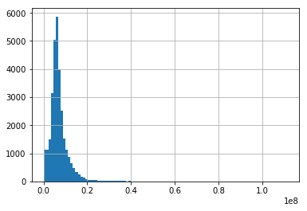

```python
df['price_doc'].hist(bins=100)
```

```python
df['log_price'] = np.log(df['price_doc'])
df.head()
```

[output not shown]

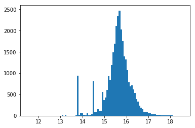

```python
plt.hist(df['log_price'], bins=100)
plt.show()
```

**Question 21: Drop the log_price column.**

```python
df = df.drop('log_price', axis=1)
```

**Question 22: Save the dataframe we have now to train_new.csv file**

```python
df.to_csv('train_new.csv')
```

**Now you've finished basic data processing for Sberbank dataset.**